# Penetración de televisión conectada, OTT y TV de pago

# Introducción

Como consecuencia de las reflexiones sobre las variables socioeconómicas y su relación con la audiencia, exploramos la posibilidad de utilizar otras variables para modelizar los minutos de consumo. Obtuvimos dos datos: los minutos de consumo en internet y la penetración de dispositivos tipo TV conectada o smart TV y de los servicios OTT y televisión de pago.

- Las fuentes de datos de los minutos de consumo en internet cambiaban en el tiempo y no cubrían el periodo agosto 2020 – diciembre 2021. Además, la serie no mostraba ninguna tendencia en el largo plazo.
- Los datos tienen una escala temporal cuatrimestral y menor discontinuidad. Además, muestran una clara tendencia al alza en el largo plazo.

Se decidió utilizar los datos de penetración. En primer lugar se elaboró un análisis para decidir qué serie utilizar, imputar los datos faltantes y encontrar una función paramétrica que ajustase la serie para después hacer un pronóstico e interpolar los datos diarios. En lugar de usar una sola serie de penetración, se decidió utilizar la media de dos de las series disponibles.

Para el ajuste y el pronóstico se utilizó una polinomial de 2º grado. Este análisis está en el Excel *Forecast TV_Datos fuentes complementarias_EGM 2018-2023* en la ruta *\01 datos\05 consumo de canales digitales*.

La interpolación de los datos diarios se realizó con el script que se presenta a continuación.

# Interpolación de datos diarios

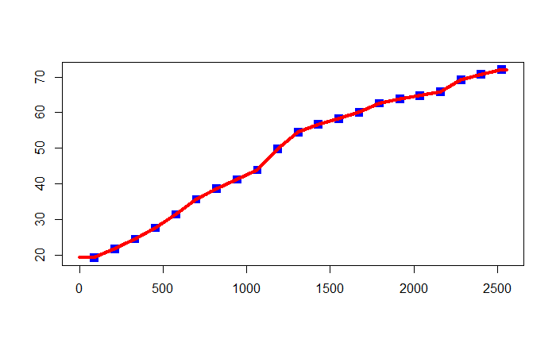

```r
library(readxl)
library(writexl)

setwd("J:/PMED_Practices/Data_Sciences/Advanced Analytics/Ninah/PROYECTOS AA/Proyecto Colaboracion UCM/01 Proyecto TV alpha/01 datos/05 consumo de canales digitales")

datos <- read_excel(path="Forecast TV_Datos fuentes complementarias_EGM 2018-2023.xlsx",
           sheet = "elaboracion - smooth", range = "G1:I2557", col_names = TRUE)

posiciones <- datos$secuencia[is.na(datos$dato)]

interpolados <- approx(datos$dato,xout=posiciones, rule=2)

plot(datos$dato,ylab="",xlab="",pch=15,col='blue',cex=1.5)
points(interpolados,pch=20,col="red",cex=0.8)
```

```r
resultado <- merge(
  datos, data.frame("interpolacion"=interpolados$y,"secuencia"=interpolados$x),
  by="secuencia", all=TRUE
)

resultado[is.na(resultado)] <- 0

resultado[,"penetracion_CTV"] <- rowSums(resultado[,c("dato","interpolacion")])
```

```r
write_xlsx(
  resultado[c("dia","penetracion_CTV")],
  path = "Forecast TV_Datos fuentes complementarias_EGM 2018-2023 - interpolacion.xlsx",
  col_names = TRUE,
  format_headers = TRUE,
  use_zip64 = FALSE
)
```